# Number of statements

Poseł Wojciech Skurkiewicz: Ale mieliście na to 8 lat.

Poseł Wojciech Skurkiewicz: Ale nie ma dyskusji.

Poseł Wojciech Skurkiewicz: Ale to są pytania tylko do sprawozdawcy, pani nie zna regulaminu.

Poseł Wojciech Skurkiewicz: Będziemy tupać nogami.

Poseł Wojciech Skurkiewicz: Był już.

Poseł Wojciech Skurkiewicz: Cała Platforma wyszła z wora.

Poseł Wojciech Skurkiewicz: Chyba że ustawa stanowi inaczej.

Poseł Wojciech Skurkiewicz: Co na to PSL?

Poseł Wojciech Skurkiewicz: Co tam słychać?

Poseł Wojciech Skurkiewicz: Co zrobiliście dla tych dzieci na wsi przez 8 lat?

Poseł Wojciech Skurkiewicz: Co zrobiliście dla wiejskich dzieci?

Poseł Wojciech Skurkiewicz: Co zrobiliście przez 8 lat dla wiejskich dzieci?

Poseł Wojciech Skurkiewicz: Czas.

Poseł Wojciech Skurkiewicz: Dbajcie o siebie.

Poseł Wojciech Skurkiewicz: Dlaczego nas pani obraża?

Poseł Wojciech Skurkiewicz: Działacze PSL-u.

Poseł Wojciech Skurkiewicz: Ekspert!

Poseł Wojciech Skurkiewicz: Gdybyście 8 lat temu to wprowadzili, to mieliby przez 10 lat.

Poseł Wojciech Skurkiewicz: Gdzie jest prokuratura?

Poseł Wojciech Skurkiewicz: Ha, ha, ha.

Poseł Wojciech Skurkiewicz: He, he, he!

Poseł Wojciech Skurkiewicz: I co po roku?

Poseł Wojciech Skurkiewicz: Jak tam na cmentarzu?

Poseł Wojciech Skurkiewicz: Jest w was.

Poseł Wojciech Skurkiewicz: Jesteśmy, słuchamy pani.

Poseł Wojciech Skurkiewicz: Jeszcze jedna linijka.

Poseł Wojciech Skurkiewicz: Kończ pan, wstydu oszczędź.

Poseł Wojciech Skurkiewicz: Koniec z polityką kapusiów.

Poseł Wojciech Skurkiewicz: Kto za to zapłacił?

Poseł Wojciech Skurkiewicz: Macie w tym doświadczenie bardzo dobre. Wszystko można zmienić.

Poseł Wojciech Skurkiewicz: Mieliście 8 lat.

Poseł Wojciech Skurkiewicz: Następni będą…

Poseł Wojciech Skurkiewicz: Nie dyskryminuj posłów.

Poseł Wojciech Skurkiewicz: Nie wstyd ci?

Poseł Wojciech Skurkiewicz: Nie.

Poseł Wojciech Skurkiewicz: Niech się Nowoczesna uczy.

Poseł Wojciech Skurkiewicz: Nieobecnej czy obecnej?

Poseł Wojciech Skurkiewicz: Niestety, ubolewamy nad tym.

Poseł Wojciech Skurkiewicz: O, proszę bardzo.

Poseł Wojciech Skurkiewicz: Obłudnicy.

Poseł Wojciech Skurkiewicz: Obywatelska była Platforma i co zostało?

Poseł Wojciech Skurkiewicz: Pamiętamy.

Poseł Wojciech Skurkiewicz: Pani Krystyno, przez ludowców tylko.

Poseł Wojciech Skurkiewicz: Pani marszałek, czas.

Poseł Wojciech Skurkiewicz: Panie marszałku, mogę?

Poseł Wojciech Skurkiewicz: Panie marszałku, odebrać im tablety. Nie będą czytać.

Poseł Wojciech Skurkiewicz: Panie marszałku, specjalnie przedłużają.

Poseł Wojciech Skurkiewicz: Panie marszałku, sprostowanie.

Poseł Wojciech Skurkiewicz: Panie marszałku…

Poseł Wojciech Skurkiewicz: Panie marszałku…

Poseł Wojciech Skurkiewicz: Panie pośle, empatia nie przyszła dzisiaj na salę.

Poseł Wojciech Skurkiewicz: Panie pośle, na tablecie pan wszystko ma.

Poseł Wojciech Skurkiewicz: Platforma.

Poseł Wojciech Skurkiewicz: Prawo i Sprawiedliwość!

Poseł Wojciech Skurkiewicz: Prof. Kieres nie był senatorem Platformy?

Poseł Wojciech Skurkiewicz: Proszę nie straszyć.

Poseł Wojciech Skurkiewicz: Przeproś za poprawkę.

Poseł Wojciech Skurkiewicz: Przez rok.

Poseł Wojciech Skurkiewicz: Senator Kieres, dwie kadencje!

Poseł Wojciech Skurkiewicz: Senator Klich.

Poseł Wojciech Skurkiewicz: Siadaj.

Poseł Wojciech Skurkiewicz: Skandal!

Poseł Wojciech Skurkiewicz: Szczególnie wiejskich. Co zrobiliście przez 8 lat?

Poseł Wojciech Skurkiewicz: Tak było przez 8 lat.

Poseł Wojciech Skurkiewicz: Tam nie było o zabijaniu.

Poseł Wojciech Skurkiewicz: To jest skandal!

Poseł Wojciech Skurkiewicz: To nie jest pytanie!

Poseł Wojciech Skurkiewicz: To u was była afera hazardowa.

Poseł Wojciech Skurkiewicz: Tylko wy jesteście najlepsi.

Poseł Wojciech Skurkiewicz: Ustawa o lasach w 26 godzin…

Poseł Wojciech Skurkiewicz: Ustawa o lasach w 26 godzin…

Poseł Wojciech Skurkiewicz: W Polakach tak.

Poseł Wojciech Skurkiewicz: W tej chwili w Senacie.

Poseł Wojciech Skurkiewicz: Wstyd to kraść.

Poseł Wojciech Skurkiewicz: Z Platformy już nie?

Poseł Wojciech Skurkiewicz: Za 20 tys. miesięcznie.

Poseł Wojciech Skurkiewicz: Ze zrozumieniem.

Poseł Wojciech Szarama: Przypominanie tych cytatów jest potrzebne.

Poseł Wojciech Szarama: To prawda!

Poseł Zbigniew Ajchler: Do Wielkopolski.

Poseł Zbigniew Ajchler: Ile więcej będę musiał płacić?

Poseł Zbigniew Ajchler: Ja też mam dzieci.

Poseł Zbigniew Ajchler: Konsultacja musi być.

Poseł Zbigniew Ajchler: O Boże!

Poseł Zbigniew Ajchler: O właśnie.

Poseł Zbigniew Ajchler: Pieniądze żeśmy zarabiali.

Poseł Zbigniew Ajchler: Właśnie.

Poseł Zbigniew Babalski: A skocznia, panie kolego? A skocznia?

Poseł Zbigniew Babalski: Co, reszta Polski się nie liczy?

Poseł Zbigniew Babalski: Czekali od 8 lat.

Poseł Zbigniew Babalski: Czy jest wolność?

Poseł Zbigniew Babalski: Do rzeczy!

Poseł Zbigniew Babalski: Ha, ha, ha, panie…

Poseł Zbigniew Babalski: Jaki mądry! Bardzo merytoryczna wypowiedź.

Poseł Zbigniew Babalski: Komisja!

Poseł Zbigniew Babalski: Milionowe.

Poseł Zbigniew Babalski: No proszę bardzo.

Poseł Zbigniew Babalski: Nowy budżet będzie. Spokojnie.

Poseł Zbigniew Babalski: Pamiętasz budżet?

Poseł Zbigniew Babalski: Panie ministrze…

Poseł Zbigniew Babalski: Przecież to było.

Poseł Zbigniew Babalski: To jest więcej, niż było.

Poseł Zbigniew Babalski: Z Platformy, oddaj…

Poseł Zbigniew Babalski: ZSL jeszcze trzeba dołożyć.

Poseł Zbigniew Biernat: O Boże…

Poseł Zbigniew Biernat: Pan wprowadza ludzi w błąd świadomie, po raz piąty.

Poseł Zbigniew Chmielowiec przemawia przy wyłączonym mikrofonie

Poseł Zbigniew Chmielowiec: Cała prawda całą dobę.

Poseł Zbigniew Chmielowiec: Czy cię pogrzało?

Poseł Zbigniew Chmielowiec: Nie ma tam dzieci.

Poseł Zbigniew Chmielowiec: U nas nie ma takich.

Poseł Zbigniew Dolata: 500 zł na dziecko proponujemy.

Poseł Zbigniew Dolata: A Finlandia?

Poseł Zbigniew Dolata: Ale daliśmy tę możliwość, panie pośle, daliśmy.

Poseł Zbigniew Dolata: Ale gdzie pani to znalazła?

Poseł Zbigniew Dolata: Ale mogą sześciolatki pójść do szkoły.

Poseł Zbigniew Dolata: Ale przecież mogą.

Poseł Zbigniew Dolata: Ale rodzice są za.

Poseł Zbigniew Dolata: Byle nie zmuszać.

Poseł Zbigniew Dolata: Były brane pod uwagę.

Poseł Zbigniew Dolata: Chcą się wycofać z tego.

Poseł Zbigniew Dolata: Czekamy, czekamy.

Poseł Zbigniew Dolata: Dlaczego wyrzuciliście to do kosza?

Poseł Zbigniew Dolata: Gdzie pani to wyczytała?

Poseł Zbigniew Dolata: Kasandra, po prostu Kasandra.

Poseł Zbigniew Dolata: Ma się dobrze.

Poseł Zbigniew Dolata: Na wniosek rodzica.

Poseł Zbigniew Dolata: Nieprawda.

Poseł Zbigniew Dolata: Pan się nie martwi.

Poseł Zbigniew Dolata: Pani czas minął!

Poseł Zbigniew Dolata: Pani poseł Lubnauer mówiła coś innego.

Poseł Zbigniew Dolata: Polityka to roztropna troska o dobro wspólne.

Poseł Zbigniew Dolata: Poprawkę taką zgłośmy.

Poseł Zbigniew Dolata: Skąd pani to wie?

Poseł Zbigniew Dolata: Słuchać…

Poseł Zbigniew Dolata: Specjalista od słuchania.

Poseł Zbigniew Dolata: Straciliście połowę klubu.

Poseł Zbigniew Dolata: Tak.

Poseł Zbigniew Dolata: To już było, pani poseł.

Poseł Zbigniew Dolata: To proszę przeczytać tę ustawę.

Poseł Zbigniew Dolata: To ryzykowna teza.

Poseł Zbigniew Dolata: Trzeba słuchać Polaków.

Poseł Zbigniew Dolata: Trzeba słuchać rodziców.

Poseł Zbigniew Dolata: Tylko kompetencje.

Poseł Zbigniew Dolata: Właśnie, o to chodzi. O to chodzi.

Poseł Zbigniew Dolata: Wpłynęła.

Poseł Zbigniew Dolata: XIX w. był piękny.

Poseł Zbigniew Dolata: Zdarta płyta.

Poseł Zbigniew Dolata: Zdziwisz się.

Poseł Zbigniew Dolata: Źle czytałeś. Chcesz ulotkę?

Poseł Zbigniew Konwiński odtwarza z tabletu fragment nagrania z kampanii Beaty Szydło: 500 zł na każde dziecko, 500 zł na każde dziecko, 500 zł na każde dziecko…, oklaski

Poseł Zbigniew Konwiński: ˝I˝ zostało. Samo ˝i˝.

Poseł Zbigniew Konwiński: Czas!

Poseł Zbigniew Konwiński: Czasu pan nie zatrzymywał kilka razy. Teraz też pan nie zatrzymał czasu.

Poseł Zbigniew Konwiński: Sprostowanie!

Poseł Zbigniew Konwiński: Trzeba się przygotowywać do wystąpień.

Poseł Zbigniew Konwiński: W piekle się pan będzie smażył za to. Do spowiedzi.

Poseł Zbigniew Sosnowski: A pan poseł głosował za tym bublem czy był przeciw?

Poseł Zbigniew Sosnowski: Nasza ustawa w tym wam nie przeszkadza.

Poseł Zbigniew Sosnowski: Pan się stara cały czas, panie pośle. Pan się stara cały czas.

Poseł Zbigniew Sosnowski: Pani marszałek, w sprawie formalnej.

Poseł Zbigniew Sosnowski: Panie marszałku, sprostowanie.

Poseł Zbigniew Ziobro: A w PZPR był?

Poseł Zbigniew Ziobro: Na podstawie regulaminu.

Poseł Zbigniew Ziobro: Nauczcie się czytać.

Poseł Zbigniew Ziobro: Ooo…

Poseł Zbigniew Ziobro: Praktyka czyni mistrza.

Poseł Zbigniew Ziobro: Żona sędziego to sędzina.

Poseł Zdzisław Gawlik: Nie.

Poseł Zdzisław Gawlik: To wynika z tej ustawy…

## Kto komu przerywa

|  | kto_klub | Kukiz15 | N | PiS | PO | PSL |
| --- | --- | --- | --- | --- | --- | --- |
| 1 | Kukiz15 | 19 | 5 | 78 | 185 | 6 |
| 2 | N | 39 | 23 | 491 | 124 | 7 |
| 3 | niez. | 0 | 0 | 10 | 19 | 0 |
| 4 | PiS | 28 | 56 | 418 | 1522 | 66 |
| 5 | PO | 21 | 6 | 1127 | 344 | 6 |
| 6 | PSL | 4 | 6 | 205 | 57 | 5 |

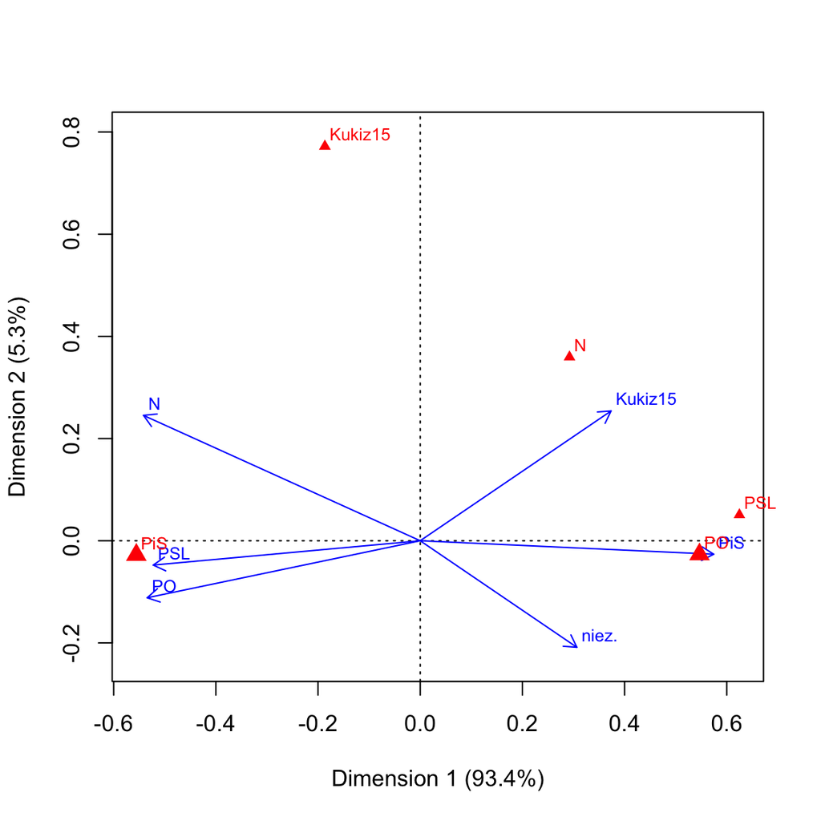